# STATS 330 Assignment 4

Rudklao Raviyan ID 2590622 UPI: rrav628

Due Date: 11.59pm, Friday 9th February 2023

# 1 Question 1

```r
data.df = read.csv("Ass4STATS330.csv")
summary(data.df[,c("dwhf","ejf_per","trtmt1")])
```

```
##       dwhf           ejf_per          trtmt1
##  Min.   :0.0000   Min.   : 3.00   Min.   :0.0000
##  1st Qu.:0.0000   1st Qu.:22.00   1st Qu.:0.0000
##  Median :0.0000   Median :29.00   Median :0.0000
##  Mean   :0.3412   Mean   :28.64   Mean   :0.4983
##  3rd Qu.:1.0000   3rd Qu.:35.00   3rd Qu.:1.0000
##  Max.   :1.0000   Max.   :45.00   Max.   :1.0000
```

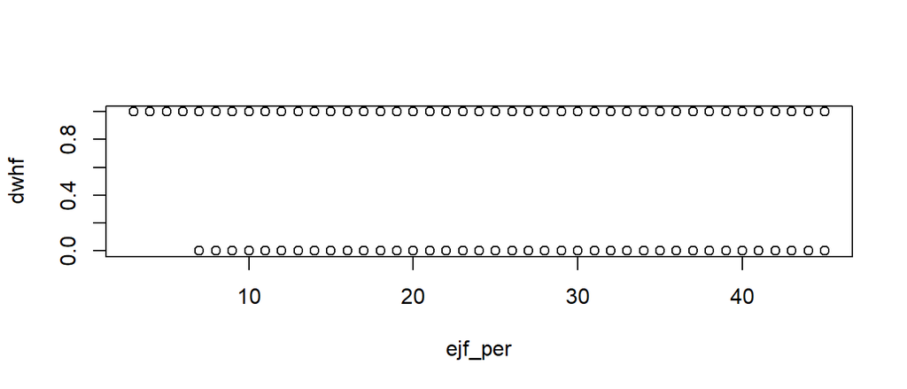

```r
plot(dwhf ~ ejf_per, data = data.df)
```

```r
q1=data.df[,c("dwhf","ejf_per","trtmt1")]
str(q1)
```

```
## 'data.frame':    4000 obs. of  3 variables:
##  $ dwhf   : int  1 1 1 0 1 0 0 0 0 0 ...
##  $ ejf_per: int  40 12 36 31 15 45 30 39 33 24 ...
##  $ trtmt1 : int  0 0 0 1 0 0 1 1 0 1 ...
```

```r
q1$trtmt1=factor(q1$trtmt1,levels = c(0,1),labels=c("Placebo","Digoxin"))

tmp=q1 %>% group_by(trtmt1,ejf_per) %>% summarise(prop = mean(dwhf),event=sum(dwhf), n = n())
print(tmp)
```

```
## # A tibble: 82 × 5
## # Groups:   trtmt1 [2]
##    trtmt1  ejf_per  prop event     n
##    <fct>     <int> <dbl> <int> <int>
##  1 Placebo       3 1         1     1
##  2 Placebo       4 1         1     1
##  3 Placebo       5 1         1     1
##  4 Placebo       8 0.714     5     7
##  5 Placebo       9 0.75      3     4
##  6 Placebo      10 0.667    12    18
##  7 Placebo      11 0.833    10    12
##  8 Placebo      12 0.526    10    19
##  9 Placebo      13 0.731    19    26
## 10 Placebo      14 0.731    19    26
## # … with 72 more rows
```

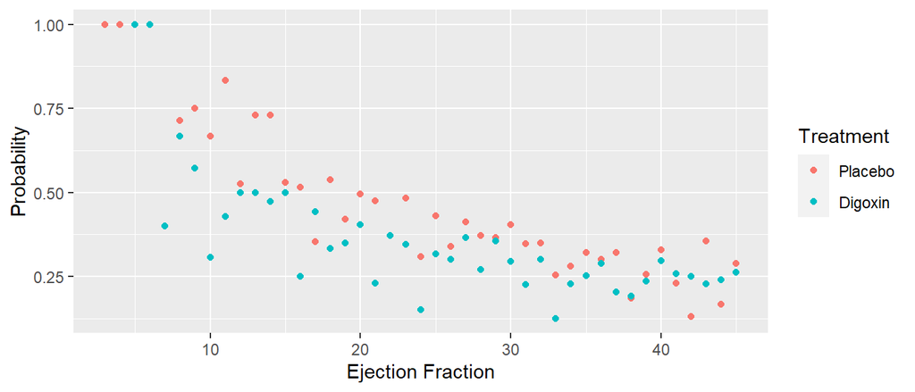

```r
ggplot(tmp,aes(x=ejf_per,y=prop, color=trtmt1))+geom_point()+xlab("Ejection Fraction") + labs(color='Treatment')+ ylab("Probability")
```

First we start exploring the data by looking at the summary and types of variables of our interested variables. We gathered that ejf_per is an integer while trtmt1 is the categorical data. The dwhf variable is described by R that it is an integer but infact, it is a categorical factor as it takes the value of either 0 or 1. From the raw data, we are interested in the treatment the patient actually received because patients may be allocate to placebo or Digoxin group but they may actually received different treatment from their allocated group, hence treatment1 variable was used in this analysis.

Then we plot a graph to see the relationship between the ejf_per and dwhf. Graph showed that the scatters are either at 0 or 1 hence, the response variable(dwhf) have a binomial distribution. Next we grouped the data into ejeculation fraction rate and treatment received. From the graph, we can see that the lower the ejection fraction, the higher probability of death with health failure. The trend exponentialy decreased as the ejection fraction increases however, both placebo and digoxin group seems to performed similary.

## 1.1 plot and explore data, model selections

```r
ejection.fit1 = glm(dwhf ~ ejf_per + trtmt1, data = data.df, family = "binomial")
summary(ejection.fit1)
```

```
##
## Call:
## glm(formula = dwhf ~ ejf_per + trtmt1, family = "binomial", data = data.df)
##
## Deviance Residuals:
##     Min       1Q   Median       3Q      Max
## -1.3413  -0.9228  -0.7732   1.3056   1.8744
##
## Coefficients:
##              Estimate Std. Error z value Pr(>|z|)
## (Intercept)  0.714408   0.119111   5.998 2.00e-09 ***
## ejf_per     -0.042118   0.003933 -10.710  < 2e-16 ***
## trtmt1      -0.386407   0.068130  -5.672 1.41e-08 ***
## ---
## Signif. codes:  0 '***' 0.001 '**' 0.01 '*' 0.05 '.' 0.1 ' ' 1
##
## (Dispersion parameter for binomial family taken to be 1)
##
##     Null deviance: 5134.9  on 3999  degrees of freedom
## Residual deviance: 4984.2  on 3997  degrees of freedom
## AIC: 4990.2
##
## Number of Fisher Scoring iterations: 4
```

After the data exploration, we are continuing with model selection. First we fitted the interested variable, the treatment patient received, and the response variable, death with hearth failure (ejection.fit1). It is the full model and from the summary, all the variables included in the model have significant relationship with the response variable due to the p-value.

```r
data.gam.fit = gam(dwhf ~ s(ejf_per) + trtmt1 , family = "binomial", data = data.df)
summary(data.gam.fit)
```

```
##
## Family: binomial
## Link function: logit
##
## Formula:
## dwhf ~ s(ejf_per) + trtmt1
##
## Parametric coefficients:
##             Estimate Std. Error z value Pr(>|z|)
## (Intercept) -0.49050    0.04675  -10.49  < 2e-16 ***
## trtmt1      -0.38464    0.06820   -5.64  1.7e-08 ***
## ---
## Signif. codes:  0 '***' 0.001 '**' 0.01 '*' 0.05 '.' 0.1 ' ' 1
##
## Approximate significance of smooth terms:
##              edf Ref.df Chi.sq p-value
## s(ejf_per) 2.351  2.965  121.5  <2e-16 ***
## ---
## Signif. codes:  0 '***' 0.001 '**' 0.01 '*' 0.05 '.' 0.1 ' ' 1
##
## R-sq.(adj) =   0.04   Deviance explained = 3.09%
## UBRE = 0.24624  Scale est. = 1         n = 4000
```

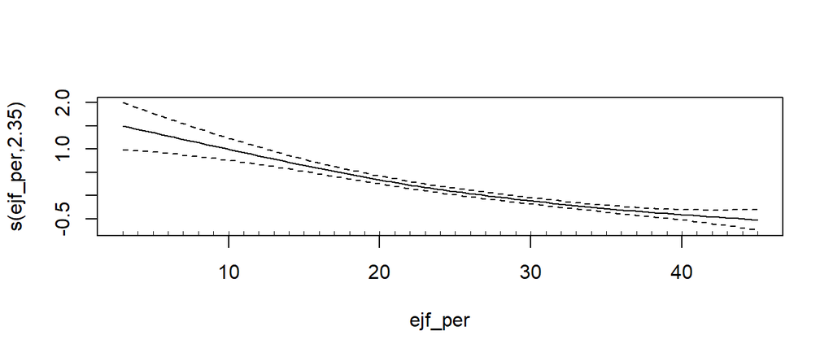

```r
plot(data.gam.fit)
```

```r
ejection.gam.fit2 = glm(dwhf ~ ejf_per + I(ejf_per^2) + trtmt1 , family = "binomial", data = data.df)
summary(ejection.gam.fit2)
```

```
##
## Call:
## glm(formula = dwhf ~ ejf_per + I(ejf_per^2) + trtmt1, family = "binomial",
##     data = data.df)
##
## Deviance Residuals:
##     Min       1Q   Median       3Q      Max
## -1.5003  -0.8981  -0.7745   1.2967   1.7579
##
## Coefficients:
##                Estimate Std. Error z value Pr(>|z|)
## (Intercept)   1.5059883  0.3020621   4.986 6.17e-07 ***
## ejf_per      -0.1058243  0.0226131  -4.680 2.87e-06 ***
## I(ejf_per^2)  0.0011530  0.0004017   2.870   0.0041 **
## trtmt1       -0.3840047  0.0682367  -5.628 1.83e-08 ***
## ---
## Signif. codes:  0 '***' 0.001 '**' 0.01 '*' 0.05 '.' 0.1 ' ' 1
##
## (Dispersion parameter for binomial family taken to be 1)
##
##     Null deviance: 5134.9  on 3999  degrees of freedom
## Residual deviance: 4976.0  on 3996  degrees of freedom
## AIC: 4984
##
## Number of Fisher Scoring iterations: 4
```

```r
confint(ejection.gam.fit2)
```

```
##                      2.5 %       97.5 %
## (Intercept)   0.9158869208  2.100623467
## ejf_per      -0.1502557536 -0.061573623
## I(ejf_per^2)  0.0003651388  0.001940529
## trtmt1       -0.5179565625 -0.250438830
```

Next we explore the model if there are any quadratic relationship requirement. We use gam funciton to do so (data.gam.fit). From the summary of the gam plot and the plot itself, we can see that, we can almost fit the straightline between the dotted lines but the edf is greater than 1, hence it suggests that we indeed need a quadratic term for the ejf_per variable. From the summary, the p-value for the 2nd order quadratic term on ejf_per variable is significant.

```r
ejection.fit2 = glm(dwhf ~ (ejf_per + I(ejf_per^2)) * trtmt1, data = data.df, family = "binomial")
summary(ejection.fit2)
```

```
##
## Call:
## glm(formula = dwhf ~ (ejf_per + I(ejf_per^2)) * trtmt1, family = "binomial",
##     data = data.df)
##
## Deviance Residuals:
##     Min       1Q   Median       3Q      Max
## -1.5812  -0.8848  -0.7765   1.3207   1.6796
##
## Coefficients:
##                       Estimate Std. Error z value Pr(>|z|)
## (Intercept)          1.7505128  0.4271430   4.098 4.16e-05 ***
## ejf_per             -0.1137689  0.0320109  -3.554 0.000379 ***
## I(ejf_per^2)         0.0011271  0.0005661   1.991 0.046485 *
## trtmt1              -0.8567364  0.6041512  -1.418 0.156167
## ejf_per:trtmt1       0.0133803  0.0454179   0.295 0.768297
## I(ejf_per^2):trtmt1  0.0001173  0.0008059   0.145 0.884318
## ---
## Signif. codes:  0 '***' 0.001 '**' 0.01 '*' 0.05 '.' 0.1 ' ' 1
##
## (Dispersion parameter for binomial family taken to be 1)
##
##     Null deviance: 5134.9  on 3999  degrees of freedom
## Residual deviance: 4969.5  on 3994  degrees of freedom
## AIC: 4981.5
##
## Number of Fisher Scoring iterations: 4
```

```r
ejection.fit3 = glm(dwhf ~ ejf_per * trtmt1 + I(ejf_per^2), data = data.df, family = "binomial")
summary(ejection.fit3)
```

```
##
## Call:
## glm(formula = dwhf ~ ejf_per * trtmt1 + I(ejf_per^2), family = "binomial",
##     data = data.df)
##
## Deviance Residuals:
##     Min       1Q   Median       3Q      Max
## -1.5895  -0.8835  -0.7777   1.3222   1.6821
##
## Coefficients:
##                  Estimate Std. Error z value Pr(>|z|)
## (Intercept)     1.7910808  0.3240355   5.527 3.25e-08 ***
## ejf_per        -0.1169941  0.0231165  -5.061 4.17e-07 ***
## trtmt1         -0.9381354  0.2283135  -4.109 3.97e-05 ***
## I(ejf_per^2)    0.0011850  0.0004031   2.940  0.00328 **
## ejf_per:trtmt1  0.0198905  0.0078076   2.548  0.01085 *
## ---
## Signif. codes:  0 '***' 0.001 '**' 0.01 '*' 0.05 '.' 0.1 ' ' 1
##
## (Dispersion parameter for binomial family taken to be 1)
##
##     Null deviance: 5134.9  on 3999  degrees of freedom
## Residual deviance: 4969.5  on 3995  degrees of freedom
## AIC: 4979.5
##
## Number of Fisher Scoring iterations: 4
```

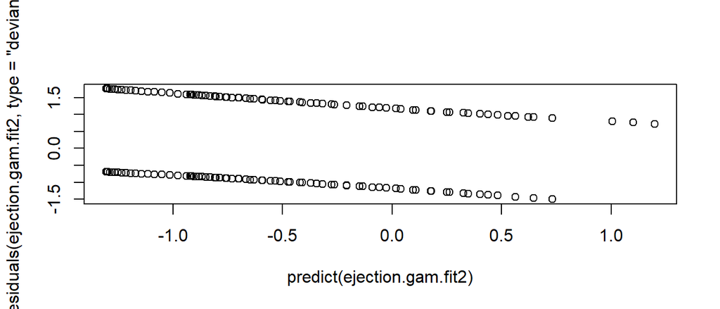

```r
plot(predict(ejection.gam.fit2),residuals(ejection.gam.fit2, type = "deviance"))
```

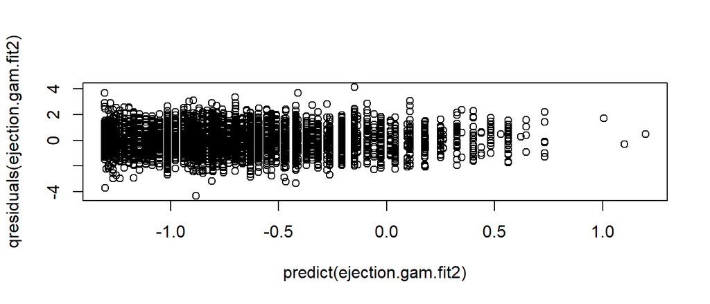

```r
plot(predict(ejection.gam.fit2), qresiduals(ejection.gam.fit2))
```

```r
set.seed(123); Nsim = 1e3
ejection.devs = numeric(Nsim); nr = nrow(data.df)
for (i in 1:Nsim){
  mos_bin = rbinom(nr, prob = predict(ejection.gam.fit2, type = "response"), 1)
  mod_i = glm(mos_bin ~ ejf_per + I(ejf_per^2) + trtmt1, data = data.df, family = "binomial")
  ejection.devs[i] = deviance(mod_i)

}
cat("GOF parametric bootstrap p-value for binomial model is")
```

```
## GOF parametric bootstrap p-value for binomial model is
```

```r
1-mean(ejection.devs < deviance(ejection.gam.fit2))
```

```
## [1] 0.485
```

After our final model selection, we conduct the Goodness of fit and model assumption via randomised quantile residual plot due to the data being sparse. It showed an approximate normal distribution scatters with small fraction of scatters greater than +/- 3 on y-axis. After the assumption is satisfied, we check the goodness of fit via parametric bootstrap where the p-value showed that this model is adequate.

## 1.2 conclusion.

Where the $ logit(_i) $ is the log odds of participant death or hospitalization due to heath failure. $ ejf_ per $ is the ejection fraction (in percent) and $ _3 $ is a dummy variable that take the value of 1 when treatment_i is Dignoxin and 0 when the treatment is placebo.

According to our research questions on how are the rate of death or hospitalization due to heart failure and the ejection fraction related. From out study, we can condluded that the relationship is quadratic and another question is whrher the relationship is the same for people taking Dignoxin and placebo. From the study, it seems to be that, if the participant received the Dignoxin treatment, the log odds of death or hospitalization is decrease by 0.38. # Question 2

## 1.3 Casual Diagram

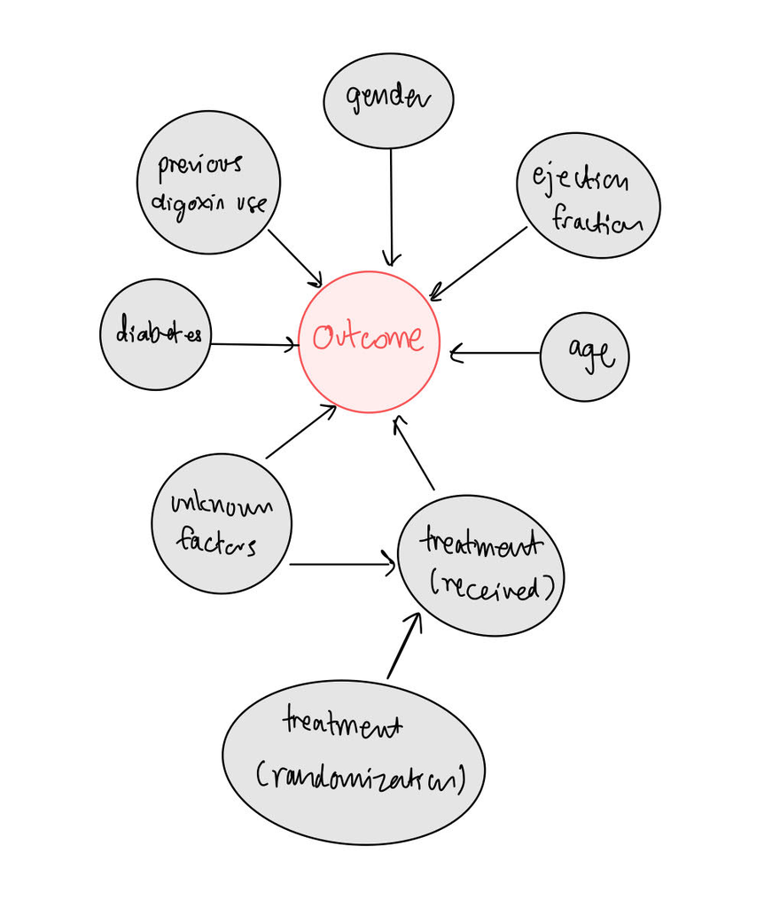

## 1.4 plot and explore data, model selections

- group data then explore the relationships

```r
data.df = read.csv("Ass4STATS330.csv")

data.df$trtmt1 = factor(data.df$trtmt1, levels = c(0,1), labels = c("Placebo", "Dignoxin"))
data.df$trtmt = factor(data.df$trtmt, levels = c(0,1), labels = c("Placebo", "Dignoxin"))
data.df$sex = factor(data.df$sex, levels = c(1,2), labels = c("Men", "Women"))
data.df$diabetes = factor(data.df$diabetes, levels = c(0,1), labels = c("Normal", "Diabetes"))
data.df$diguse = factor(data.df$diguse, levels = c(0,1), labels = c("No", "Yes"))


data.age=data.df %>% group_by(trtmt,age) %>% summarise(prop = mean(dwhf),event=sum(dwhf), n = n())
```

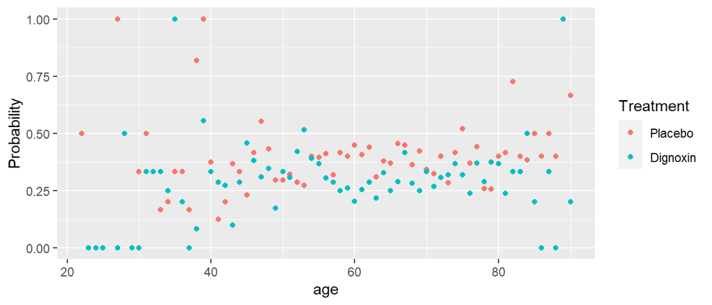

```r
ggplot(data.age,aes(x=age,y=prop, color=trtmt))+geom_point()+xlab("age") + labs(color='Treatment')+ ylab("Probability")
```

```r
data.ejf=data.df %>% group_by(trtmt,ejf_per) %>% summarise(prop = mean(dwhf),event=sum(dwhf), n = n())
```

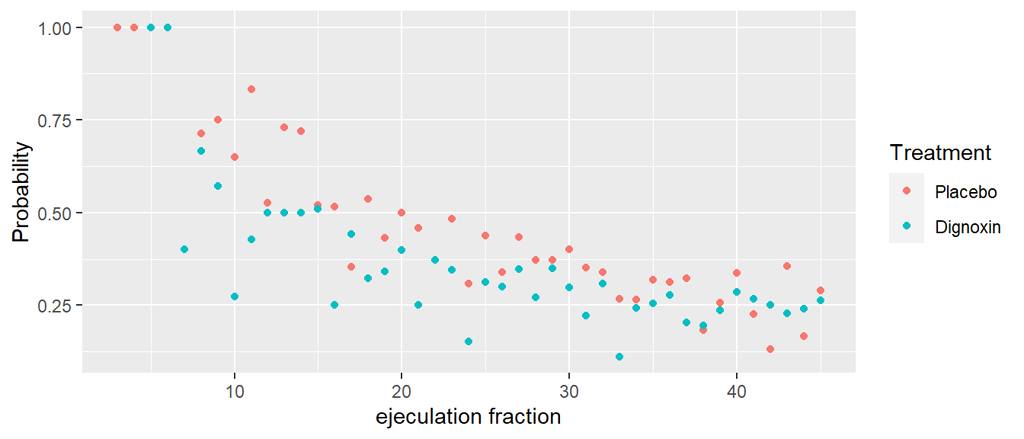

```r
ggplot(data.ejf,aes(x=ejf_per,y=prop, color=trtmt))+geom_point()+xlab("ejeculation fraction") + labs(color='Treatment')+ ylab("Probability")
```

```r
data.sex=data.df %>% group_by(trtmt,sex) %>% summarise(prop = mean(dwhf))
print(data.sex)
```

```
## # A tibble: 4 × 3
## # Groups:   trtmt [2]
##   trtmt    sex    prop
##   <fct>    <fct> <dbl>
## 1 Placebo  Men   0.388
## 2 Placebo  Women 0.371
## 3 Dignoxin Men   0.290
## 4 Dignoxin Women 0.324
```

```r
data.diabetes=data.df %>% group_by(trtmt, diabetes) %>% summarise(prop = mean(dwhf))
print(data.diabetes)
```

```
## # A tibble: 4 × 3
## # Groups:   trtmt [2]
##   trtmt    diabetes  prop
##   <fct>    <fct>    <dbl>
## 1 Placebo  Normal   0.401
## 2 Placebo  Diabetes 0.340
## 3 Dignoxin Normal   0.296
## 4 Dignoxin Diabetes 0.302
```

```r
data.dig=data.df %>% group_by(trtmt, diguse) %>% summarise(prop = mean(dwhf))
print(data.dig)
```

```
## # A tibble: 4 × 3
## # Groups:   trtmt [2]
##   trtmt    diguse  prop
##   <fct>    <fct>  <dbl>
## 1 Placebo  No     0.330
## 2 Placebo  Yes    0.452
## 3 Dignoxin No     0.252
## 4 Dignoxin Yes    0.354
```

First we explore the data to see the possible relationships between the explanatory variables and the outcome. It seems to be that the age in each Placebo and Dignoxin group all have similar possibility of death from heath failure. Similar to the ejection fraction but we can see that the trend is exponentially decreased as the ejection fraction increase so the lower the ejection fraction, the higher the possibility of death form heath failure. However, the placebo and Dignoxin group seems to perform similarly. As for the gender, the probability of death by heath failure seems to be similar whether the participants are male or female and whether the receive Placebo or Dignoxin. Howver, the probability of death from heath failure seems to be lower if the participants do not have diabetes and in Dignoxin group. As fro the previous use of Dignoxin, if the participants has no previous history of Dignoxin use regardless of what treatment group they are allocated to, the probability of death from heath failure seems to be lower and is even more lower then allocate to Dignoxin and similar trend in the previous use of Dignoxin.

```r
data.gam.fit = gam(dwhf ~ s(ejf_per) + s(age) + trtmt + sex + diabetes + diguse, family = "binomial", data = data.df)
summary(data.gam.fit)
```

```
##
## Family: binomial
## Link function: logit
##
## Formula:
## dwhf ~ s(ejf_per) + s(age) + trtmt + sex + diabetes + diguse
##
## Parametric coefficients:
##                  Estimate Std. Error z value Pr(>|z|)
## (Intercept)      -0.70050    0.06393 -10.958  < 2e-16 ***
## trtmtDignoxin    -0.39535    0.06869  -5.756 8.63e-09 ***
## sexWomen          0.12739    0.08175   1.558    0.119
## diabetesDiabetes -0.08818    0.07677  -1.149    0.251
## diguseYes         0.45241    0.06871   6.584 4.58e-11 ***
## ---
## Signif. codes:  0 '***' 0.001 '**' 0.01 '*' 0.05 '.' 0.1 ' ' 1
##
## Approximate significance of smooth terms:
##              edf Ref.df  Chi.sq p-value
## s(ejf_per) 2.410  3.039 112.816  <2e-16 ***
## s(age)     1.001  1.002   0.334   0.564
## ---
## Signif. codes:  0 '***' 0.001 '**' 0.01 '*' 0.05 '.' 0.1 ' ' 1
##
## R-sq.(adj) =  0.0514   Deviance explained = 4.05%
## UBRE = 0.23596  Scale est. = 1         n = 4000
```

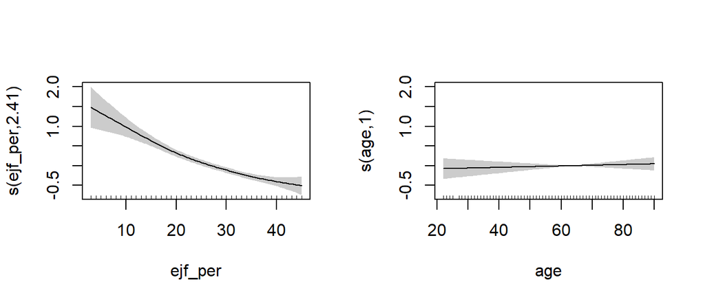

```r
plot(data.gam.fit, page = 1, shade=T)
```

```r
data.fit1 = glm(dwhf ~ ejf_per + age + trtmt + sex + diabetes + diguse, family = "binomial", data = data.df)
summary(data.fit1)
```

```
##
## Call:
## glm(formula = dwhf ~ ejf_per + age + trtmt + sex + diabetes +
##     diguse, family = "binomial", data = data.df)
##
## Deviance Residuals:
##     Min       1Q   Median       3Q      Max
## -1.4932  -0.9168  -0.7553   1.2635   2.0064
##
## Coefficients:
##                   Estimate Std. Error z value Pr(>|z|)
## (Intercept)       0.345830   0.236338   1.463    0.143
## ejf_per          -0.041086   0.003989 -10.300  < 2e-16 ***
## age               0.002022   0.003124   0.647    0.517
## trtmtDignoxin    -0.397585   0.068616  -5.794 6.86e-09 ***
## sexWomen          0.132805   0.081697   1.626    0.104
## diabetesDiabetes -0.088207   0.076695  -1.150    0.250
## diguseYes         0.452137   0.068650   6.586 4.51e-11 ***
## ---
## Signif. codes:  0 '***' 0.001 '**' 0.01 '*' 0.05 '.' 0.1 ' ' 1
##
## (Dispersion parameter for binomial family taken to be 1)
##
##     Null deviance: 5134.9  on 3999  degrees of freedom
## Residual deviance: 4934.7  on 3993  degrees of freedom
## AIC: 4948.7
##
## Number of Fisher Scoring iterations: 4
```

```r
data.fit2 = glm(dwhf ~ ejf_per + I(ejf_per^2) + age + trtmt + sex + diabetes + diguse, family = "binomial", data = data.df)
summary(data.fit2)
```

```
##
## Call:
## glm(formula = dwhf ~ ejf_per + I(ejf_per^2) + age + trtmt + sex +
##     diabetes + diguse, family = "binomial", data = data.df)
##
## Deviance Residuals:
##     Min       1Q   Median       3Q      Max
## -1.6477  -0.9098  -0.7639   1.2693   1.8932
##
## Coefficients:
##                    Estimate Std. Error z value Pr(>|z|)
## (Intercept)       1.1352313  0.3702836   3.066  0.00217 **
## ejf_per          -0.1032478  0.0227482  -4.539 5.66e-06 ***
## I(ejf_per^2)      0.0011259  0.0004044   2.784  0.00537 **
## age               0.0017564  0.0031281   0.561  0.57447
## trtmtDignoxin    -0.3944491  0.0687194  -5.740 9.47e-09 ***
## sexWomen          0.1259355  0.0817674   1.540  0.12352
## diabetesDiabetes -0.0879966  0.0768024  -1.146  0.25190
## diguseYes         0.4525657  0.0687472   6.583 4.61e-11 ***
## ---
## Signif. codes:  0 '***' 0.001 '**' 0.01 '*' 0.05 '.' 0.1 ' ' 1
##
## (Dispersion parameter for binomial family taken to be 1)
##
##     Null deviance: 5134.9  on 3999  degrees of freedom
## Residual deviance: 4927.0  on 3992  degrees of freedom
## AIC: 4943
##
## Number of Fisher Scoring iterations: 4
```

```r
anova(data.fit1, data.fit2, test = "Chisq")
```

```
## Analysis of Deviance Table
##
## Model 1: dwhf ~ ejf_per + age + trtmt + sex + diabetes + diguse
## Model 2: dwhf ~ ejf_per + I(ejf_per^2) + age + trtmt + sex + diabetes +
##     diguse
##   Resid. Df Resid. Dev Df Deviance Pr(>Chi)
## 1      3993     4934.7
## 2      3992     4927.0  1   7.7318 0.005426 **
## ---
## Signif. codes:  0 '***' 0.001 '**' 0.01 '*' 0.05 '.' 0.1 ' ' 1
```

```r
data.fit3 = glm(dwhf ~ (ejf_per + I(ejf_per^2))*trtmt + age + trtmt + sex + diabetes*trtmt + diguse, family = "binomial", data = data.df)
summary(data.fit3)
```

```
##
## Call:
## glm(formula = dwhf ~ (ejf_per + I(ejf_per^2)) * trtmt + age +
##     trtmt + sex + diabetes * trtmt + diguse, family = "binomial",
##     data = data.df)
##
## Deviance Residuals:
##     Min       1Q   Median       3Q      Max
## -1.7195  -0.8948  -0.7451   1.2720   1.8267
##
## Coefficients:
##                                  Estimate Std. Error z value Pr(>|z|)
## (Intercept)                     1.3010627  0.4771601   2.727  0.00640 **
## ejf_per                        -0.1025636  0.0318672  -3.218  0.00129 **
## I(ejf_per^2)                    0.0009627  0.0005647   1.705  0.08822 .
## trtmtDignoxin                  -0.7097292  0.6079229  -1.167  0.24302
## age                             0.0016497  0.0031311   0.527  0.59829
## sexWomen                        0.1300224  0.0819190   1.587  0.11247
## diabetesDiabetes               -0.2334890  0.1071522  -2.179  0.02933 *
## diguseYes                       0.4534227  0.0688964   6.581 4.67e-11 ***
## ejf_per:trtmtDignoxin          -0.0035875  0.0456365  -0.079  0.93734
## I(ejf_per^2):trtmtDignoxin      0.0003883  0.0008103   0.479  0.63173
## trtmtDignoxin:diabetesDiabetes  0.3035428  0.1535482   1.977  0.04806 *
## ---
## Signif. codes:  0 '***' 0.001 '**' 0.01 '*' 0.05 '.' 0.1 ' ' 1
##
## (Dispersion parameter for binomial family taken to be 1)
##
##     Null deviance: 5134.9  on 3999  degrees of freedom
## Residual deviance: 4917.4  on 3989  degrees of freedom
## AIC: 4939.4
##
## Number of Fisher Scoring iterations: 4
```

```r
options(na.action = "na.fail")
all.fits = dredge(data.fit3)
```

```
## Fixed term is "(Intercept)"
```

```r
head(all.fits)
```

```
## Global model call: glm(formula = dwhf ~ (ejf_per + I(ejf_per^2)) * trtmt + age +
##     trtmt + sex + diabetes * trtmt + diguse, family = "binomial",
##     data = data.df)
## ---
## Model selection table
##     (Int) dbt dgs ejf_per ejf_per^2 sex trt dbt:trt ejf_per:trt
## 767 1.433   +   + -0.1047 0.0009995   +   +       +
## 511 1.543   +   + -0.1134 0.0011570   +   +       +           +
## 735 1.453   +   + -0.1049 0.0010210       +       +
## 479 1.560   +   + -0.1135 0.0011750       +       +           +
## 637 1.378       + -0.1049 0.0009994   +   +
## 381 1.489       + -0.1138 0.0011600   +   +                   +
##     I(ejf_per^2):trt df    logLik   AICc delta weight
## 767                +  9 -2458.852 4935.7  0.00  0.227
## 511                   9 -2458.961 4936.0  0.22  0.204
## 735                +  8 -2460.118 4936.3  0.52  0.175
## 479                   8 -2460.210 4936.5  0.71  0.159
## 637                +  7 -2461.469 4937.0  1.22  0.124
## 381                   7 -2461.577 4937.2  1.43  0.111
## Models ranked by AICc(x)
```

```r
model.fit1 = get.models(all.fits, 1)[[1]]
summary(model.fit1)
```

```
##
## Call:
## glm(formula = dwhf ~ diabetes + diguse + ejf_per + I(ejf_per^2) +
##     sex + trtmt + diabetes:trtmt + I(ejf_per^2):trtmt + 1, family = "binomial",
##     data = data.df)
##
## Deviance Residuals:
##     Min       1Q   Median       3Q      Max
## -1.7300  -0.8930  -0.7436   1.2752   1.8316
##
## Coefficients:
##                                  Estimate Std. Error z value Pr(>|z|)
## (Intercept)                     1.4334848  0.3144973   4.558 5.16e-06 ***
## diabetesDiabetes               -0.2340189  0.1071553  -2.184   0.0290 *
## diguseYes                       0.4521039  0.0688426   6.567 5.13e-11 ***
## ejf_per                        -0.1046623  0.0228043  -4.590 4.44e-06 ***
## I(ejf_per^2)                    0.0009995  0.0004095   2.441   0.0147 *
## sexWomen                        0.1306861  0.0818843   1.596   0.1105
## trtmtDignoxin                  -0.7568879  0.1435191  -5.274 1.34e-07 ***
## diabetesDiabetes:trtmtDignoxin  0.3050129  0.1535179   1.987   0.0469 *
## I(ejf_per^2):trtmtDignoxin      0.0003255  0.0001395   2.334   0.0196 *
## ---
## Signif. codes:  0 '***' 0.001 '**' 0.01 '*' 0.05 '.' 0.1 ' ' 1
##
## (Dispersion parameter for binomial family taken to be 1)
##
##     Null deviance: 5134.9  on 3999  degrees of freedom
## Residual deviance: 4917.7  on 3991  degrees of freedom
## AIC: 4935.7
##
## Number of Fisher Scoring iterations: 4
```

```r
model.fit2 = get.models(all.fits, 2)[[1]]
summary(model.fit2)
```

```
##
## Call:
## glm(formula = dwhf ~ diabetes + diguse + ejf_per + I(ejf_per^2) +
##     sex + trtmt + diabetes:trtmt + ejf_per:trtmt + 1, family = "binomial",
##     data = data.df)
##
## Deviance Residuals:
##     Min       1Q   Median       3Q      Max
## -1.7516  -0.8945  -0.7466   1.2789   1.8182
##
## Coefficients:
##                                  Estimate Std. Error z value Pr(>|z|)
## (Intercept)                     1.5427863  0.3282945   4.699 2.61e-06 ***
## diabetesDiabetes               -0.2340005  0.1071897  -2.183   0.0290 *
## diguseYes                       0.4517607  0.0688438   6.562 5.31e-11 ***
## ejf_per                        -0.1134032  0.0232166  -4.885 1.04e-06 ***
## I(ejf_per^2)                    0.0011574  0.0004053   2.855   0.0043 **
## sexWomen                        0.1297966  0.0818695   1.585   0.1129
## trtmtDignoxin                  -0.9798958  0.2331599  -4.203 2.64e-05 ***
## diabetesDiabetes:trtmtDignoxin  0.3050824  0.1535162   1.987   0.0469 *
## ejf_per:trtmtDignoxin           0.0179671  0.0078644   2.285   0.0223 *
## ---
## Signif. codes:  0 '***' 0.001 '**' 0.01 '*' 0.05 '.' 0.1 ' ' 1
##
## (Dispersion parameter for binomial family taken to be 1)
##
##     Null deviance: 5134.9  on 3999  degrees of freedom
## Residual deviance: 4917.9  on 3991  degrees of freedom
## AIC: 4935.9
##
## Number of Fisher Scoring iterations: 4
```

```r
model.fit3 = get.models(all.fits, 3)[[1]]
summary(model.fit3)
```

```
##
## Call:
## glm(formula = dwhf ~ diabetes + diguse + ejf_per + I(ejf_per^2) +
##     trtmt + diabetes:trtmt + I(ejf_per^2):trtmt + 1, family = "binomial",
##     data = data.df)
##
## Deviance Residuals:
##     Min       1Q   Median       3Q      Max
## -1.6801  -0.8940  -0.7444   1.2774   1.8096
##
## Coefficients:
##                                  Estimate Std. Error z value Pr(>|z|)
## (Intercept)                     1.4529743  0.3141386   4.625 3.74e-06 ***
## diabetesDiabetes               -0.2331058  0.1070943  -2.177   0.0295 *
## diguseYes                       0.4530750  0.0688169   6.584 4.59e-11 ***
## ejf_per                        -0.1049479  0.0227934  -4.604 4.14e-06 ***
## I(ejf_per^2)                    0.0010211  0.0004091   2.496   0.0126 *
## trtmtDignoxin                  -0.7532032  0.1434285  -5.251 1.51e-07 ***
## diabetesDiabetes:trtmtDignoxin  0.3086010  0.1534389   2.011   0.0443 *
## I(ejf_per^2):trtmtDignoxin      0.0003182  0.0001393   2.283   0.0224 *
## ---
## Signif. codes:  0 '***' 0.001 '**' 0.01 '*' 0.05 '.' 0.1 ' ' 1
##
## (Dispersion parameter for binomial family taken to be 1)
##
##     Null deviance: 5134.9  on 3999  degrees of freedom
## Residual deviance: 4920.2  on 3992  degrees of freedom
## AIC: 4936.2
##
## Number of Fisher Scoring iterations: 4
```

```r
model.fit4 = get.models(all.fits, 4)[[1]]
summary(model.fit4)
```

```
##
## Call:
## glm(formula = dwhf ~ diabetes + diguse + ejf_per + I(ejf_per^2) +
##     trtmt + diabetes:trtmt + ejf_per:trtmt + 1, family = "binomial",
##     data = data.df)
##
## Deviance Residuals:
##     Min       1Q   Median       3Q      Max
## -1.7018  -0.8969  -0.7484   1.2808   1.7966
##
## Coefficients:
##                                 Estimate Std. Error z value Pr(>|z|)
## (Intercept)                     1.560287   0.327941   4.758 1.96e-06 ***
## diabetesDiabetes               -0.233097   0.107130  -2.176  0.02957 *
## diguseYes                       0.452708   0.068819   6.578 4.76e-11 ***
## ejf_per                        -0.113513   0.023203  -4.892 9.98e-07 ***
## I(ejf_per^2)                    0.001175   0.000405   2.902  0.00371 **
## trtmtDignoxin                  -0.972432   0.232999  -4.174 3.00e-05 ***
## diabetesDiabetes:trtmtDignoxin  0.308636   0.153438   2.011  0.04428 *
## ejf_per:trtmtDignoxin           0.017607   0.007857   2.241  0.02504 *
## ---
## Signif. codes:  0 '***' 0.001 '**' 0.01 '*' 0.05 '.' 0.1 ' ' 1
##
## (Dispersion parameter for binomial family taken to be 1)
##
##     Null deviance: 5134.9  on 3999  degrees of freedom
## Residual deviance: 4920.4  on 3992  degrees of freedom
## AIC: 4936.4
##
## Number of Fisher Scoring iterations: 4
```

```r
model.fit5 = get.models(all.fits, 5)[[1]]
summary(model.fit5)
```

```
##
## Call:
## glm(formula = dwhf ~ diguse + ejf_per + I(ejf_per^2) + sex +
##     trtmt + I(ejf_per^2):trtmt + 1, family = "binomial", data = data.df)
##
## Deviance Residuals:
##     Min       1Q   Median       3Q      Max
## -1.7038  -0.8936  -0.7467   1.2736   1.7860
##
## Coefficients:
##                              Estimate Std. Error z value Pr(>|z|)
## (Intercept)                 1.3775741  0.3132504   4.398 1.09e-05 ***
## diguseYes                   0.4512205  0.0687287   6.565 5.19e-11 ***
## ejf_per                    -0.1049141  0.0227959  -4.602 4.18e-06 ***
## I(ejf_per^2)                0.0009994  0.0004093   2.441   0.0146 *
## sexWomen                    0.1311644  0.0818242   1.603   0.1089
## trtmtDignoxin              -0.6780705  0.1375817  -4.928 8.29e-07 ***
## I(ejf_per^2):trtmtDignoxin  0.0003313  0.0001394   2.377   0.0175 *
## ---
## Signif. codes:  0 '***' 0.001 '**' 0.01 '*' 0.05 '.' 0.1 ' ' 1
##
## (Dispersion parameter for binomial family taken to be 1)
##
##     Null deviance: 5134.9  on 3999  degrees of freedom
## Residual deviance: 4922.9  on 3993  degrees of freedom
## AIC: 4936.9
##
## Number of Fisher Scoring iterations: 4
```

```r
anova(model.fit4, data.fit3, test = "Chisq")
```

```
## Analysis of Deviance Table
##
## Model 1: dwhf ~ diabetes + diguse + ejf_per + I(ejf_per^2) + trtmt + diabetes:trtmt +
##     ejf_per:trtmt + 1
## Model 2: dwhf ~ (ejf_per + I(ejf_per^2)) * trtmt + age + trtmt + sex +
##     diabetes * trtmt + diguse
##   Resid. Df Resid. Dev Df Deviance Pr(>Chi)
## 1      3992     4920.4
## 2      3989     4917.4  3   2.9996   0.3917
```

```r
summary(data.fit3)
```

```
##
## Call:
## glm(formula = dwhf ~ (ejf_per + I(ejf_per^2)) * trtmt + age +
##     trtmt + sex + diabetes * trtmt + diguse, family = "binomial",
##     data = data.df)
##
## Deviance Residuals:
##     Min       1Q   Median       3Q      Max
## -1.7195  -0.8948  -0.7451   1.2720   1.8267
##
## Coefficients:
##                                  Estimate Std. Error z value Pr(>|z|)
## (Intercept)                     1.3010627  0.4771601   2.727  0.00640 **
## ejf_per                        -0.1025636  0.0318672  -3.218  0.00129 **
## I(ejf_per^2)                    0.0009627  0.0005647   1.705  0.08822 .
## trtmtDignoxin                  -0.7097292  0.6079229  -1.167  0.24302
## age                             0.0016497  0.0031311   0.527  0.59829
## sexWomen                        0.1300224  0.0819190   1.587  0.11247
## diabetesDiabetes               -0.2334890  0.1071522  -2.179  0.02933 *
## diguseYes                       0.4534227  0.0688964   6.581 4.67e-11 ***
## ejf_per:trtmtDignoxin          -0.0035875  0.0456365  -0.079  0.93734
## I(ejf_per^2):trtmtDignoxin      0.0003883  0.0008103   0.479  0.63173
## trtmtDignoxin:diabetesDiabetes  0.3035428  0.1535482   1.977  0.04806 *
## ---
## Signif. codes:  0 '***' 0.001 '**' 0.01 '*' 0.05 '.' 0.1 ' ' 1
##
## (Dispersion parameter for binomial family taken to be 1)
##
##     Null deviance: 5134.9  on 3999  degrees of freedom
## Residual deviance: 4917.4  on 3989  degrees of freedom
## AIC: 4939.4
##
## Number of Fisher Scoring iterations: 4
```

```r
summary(model.fit4)
```

```
##
## Call:
## glm(formula = dwhf ~ diabetes + diguse + ejf_per + I(ejf_per^2) +
##     trtmt + diabetes:trtmt + ejf_per:trtmt + 1, family = "binomial",
##     data = data.df)
##
## Deviance Residuals:
##     Min       1Q   Median       3Q      Max
## -1.7018  -0.8969  -0.7484   1.2808   1.7966
##
## Coefficients:
##                                 Estimate Std. Error z value Pr(>|z|)
## (Intercept)                     1.560287   0.327941   4.758 1.96e-06 ***
## diabetesDiabetes               -0.233097   0.107130  -2.176  0.02957 *
## diguseYes                       0.452708   0.068819   6.578 4.76e-11 ***
## ejf_per                        -0.113513   0.023203  -4.892 9.98e-07 ***
## I(ejf_per^2)                    0.001175   0.000405   2.902  0.00371 **
## trtmtDignoxin                  -0.972432   0.232999  -4.174 3.00e-05 ***
## diabetesDiabetes:trtmtDignoxin  0.308636   0.153438   2.011  0.04428 *
## ejf_per:trtmtDignoxin           0.017607   0.007857   2.241  0.02504 *
## ---
## Signif. codes:  0 '***' 0.001 '**' 0.01 '*' 0.05 '.' 0.1 ' ' 1
##
## (Dispersion parameter for binomial family taken to be 1)
##
##     Null deviance: 5134.9  on 3999  degrees of freedom
## Residual deviance: 4920.4  on 3992  degrees of freedom
## AIC: 4936.4
##
## Number of Fisher Scoring iterations: 4
```

```r
predictions = predict(model.fit4, type = "response")

set.seed(1234)
Nsim = 1e4
nb.devs = numeric(Nsim); nr = nrow(data.df)
for (i in 1:Nsim){
  out = rbinom(nr, prob = predict(model.fit4, type = "response"), 1)
  data.df$out = out
  mod_i = glm(out ~ diabetes + diguse + ejf_per + I(ejf_per^2) +
    trtmt + diabetes*trtmt + ejf_per*trtmt + 1, family = "binomial", data = data.df)
  nb.devs[i] = deviance(mod_i)
}
cat("GOF parametric bootstrap p=value for the model is ")
```

```
## GOF parametric bootstrap p=value for the model is
```

```r
1 - mean(nb.devs < deviance(model.fit4))
```

```
## [1] 0.441
```

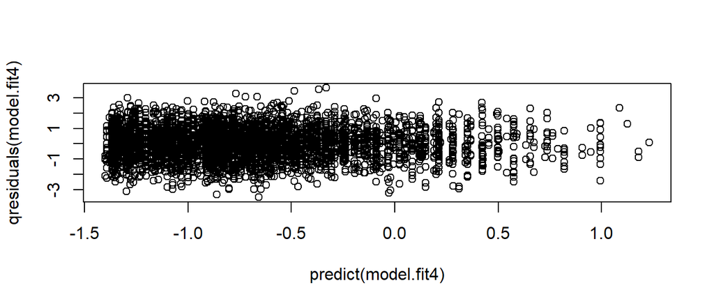

```r
plot(predict(model.fit4), qresiduals(model.fit4))
```

After we explore the possible relationships with the explanatory variables, we are interested to see if there are any quadratic relationships. From the gam plot(data.gam.fit), we can see that the edf of ejf_per is 2.4 while age is 1 so we need a quadratic term for ejf_per variable. We fitted the model with quadratic term (data.fit2) Comparing the AIC score between the the model without the quadratic term (data.fit1), we can see that the AIC score is smaller when there is a quadratic term for ejf_per variable.

Next we are interested in whether there are interaction terms between different variables. From the data exploration, we can see that there are possible interactions between treatment with ejf_per, Diabetes and previous Dignoxin use. From the dredge function, we tried to find the best model according to the AIC scores, we selected the best 5 models and evaluted the p-values of each variables selected by the dredge function. We decided to select model 479 which is the 4th best model (model.fit4) based on the data exploration that the treatment group and ejection fraction seems to have interaction. There is a better model that included the mentioned interaction but it also included sex which from the p-value, it seems to have insignificant relationship with the dwhf so we decided to pick this model.

we conducted the model assumption and goodness of fit via randomised quantile residual plots as the data is sparse and parametric bootstrap. The randomised quantile residule showed an approximately normal distribution with small fraction of scatters over +/- 3 magnitude in y-axis. The p-value generated from parametric bootstrap suggests that there is no evidence model inadequate.

```r
library(emmeans)
summary(model.fit4)
```

```
##
## Call:
## glm(formula = dwhf ~ diabetes + diguse + ejf_per + I(ejf_per^2) +
##     trtmt + diabetes:trtmt + ejf_per:trtmt + 1, family = "binomial",
##     data = data.df)
##
## Deviance Residuals:
##     Min       1Q   Median       3Q      Max
## -1.7018  -0.8969  -0.7484   1.2808   1.7966
##
## Coefficients:
##                                 Estimate Std. Error z value Pr(>|z|)
## (Intercept)                     1.560287   0.327941   4.758 1.96e-06 ***
## diabetesDiabetes               -0.233097   0.107130  -2.176  0.02957 *
## diguseYes                       0.452708   0.068819   6.578 4.76e-11 ***
## ejf_per                        -0.113513   0.023203  -4.892 9.98e-07 ***
## I(ejf_per^2)                    0.001175   0.000405   2.902  0.00371 **
## trtmtDignoxin                  -0.972432   0.232999  -4.174 3.00e-05 ***
## diabetesDiabetes:trtmtDignoxin  0.308636   0.153438   2.011  0.04428 *
## ejf_per:trtmtDignoxin           0.017607   0.007857   2.241  0.02504 *
## ---
## Signif. codes:  0 '***' 0.001 '**' 0.01 '*' 0.05 '.' 0.1 ' ' 1
##
## (Dispersion parameter for binomial family taken to be 1)
##
##     Null deviance: 5134.9  on 3999  degrees of freedom
## Residual deviance: 4920.4  on 3992  degrees of freedom
## AIC: 4936.4
##
## Number of Fisher Scoring iterations: 4
```

```r
odds = exp(model.fit4$coefficients)
odds
```

```
##                    (Intercept)               diabetesDiabetes
##                      4.7601860                      0.7920771
##                      diguseYes                        ejf_per
##                      1.5725650                      0.8926928
##                   I(ejf_per^2)                  trtmtDignoxin
##                      1.0011760                      0.3781623
## diabetesDiabetes:trtmtDignoxin          ejf_per:trtmtDignoxin
##                      1.3615664                      1.0177631
```

```r
ORs=exp(confint((model.fit4)))
ORs
```

```
##                                    2.5 %    97.5 %
## (Intercept)                    2.5096847 9.0827328
## diabetesDiabetes               0.6413363 0.9762045
## diguseYes                      1.3742534 1.7998615
## ejf_per                        0.8528941 0.9341440
## I(ejf_per^2)                   1.0003811 1.0019711
## trtmtDignoxin                  0.2393143 0.5966466
## diabetesDiabetes:trtmtDignoxin 1.0077939 1.8392937
## ejf_per:trtmtDignoxin          1.0022114 1.0335682
```

```r
compare1 = emmeans(model.fit4, pairwise  ~ diabetes * trtmt, type = "response")
compare1$contrasts
```

```
##  contrast                             odds.ratio    SE  df null z.ratio p.value
##  Normal Placebo / Diabetes Placebo         1.263 0.135 Inf    1   2.176  0.1300
##  Normal Placebo / Normal Dignoxin          1.597 0.130 Inf    1   5.767  <.0001
##  Normal Placebo / Diabetes Dignoxin        1.481 0.160 Inf    1   3.644  0.0015
##  Diabetes Placebo / Normal Dignoxin        1.265 0.138 Inf    1   2.148  0.1381
##  Diabetes Placebo / Diabetes Dignoxin      1.173 0.153 Inf    1   1.224  0.6115
##  Normal Dignoxin / Diabetes Dignoxin       0.927 0.102 Inf    1  -0.688  0.9019
##
## Results are averaged over the levels of: diguse
## P value adjustment: tukey method for comparing a family of 4 estimates
## Tests are performed on the log odds ratio scale
```

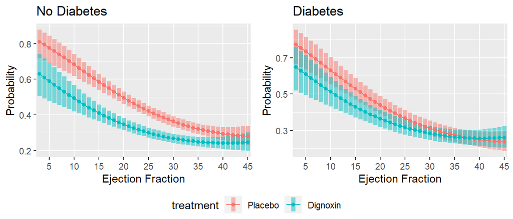

```r
tmp = summary(compare1$contrasts)

p1 = emmip (model.fit4, trtmt ~ ejf_per *diabetes,
at = list(ejf_per = 3:45, diabetes = "Normal"), type = "response", CIs = TRUE) + xlab("Ejection Fraction") + ylab("Probability")+
scale_x_discrete(breaks = paste(3:45, "Normal")[seq(from = 3, to = 45, by=5)], labels = c(3:45)
[seq(from = 3, to=45, by = 5)]) + labs(color = 'treatment') + ggtitle("No Diabetes")

p2 = emmip (model.fit4, trtmt ~ ejf_per *diabetes,
at = list(ejf_per = 3:45, diabetes = "Diabetes"), type = "response", CIs = TRUE) + xlab("Ejection Fraction") + ylab("Probability")+
scale_x_discrete(breaks = paste(3:45, "Diabetes")[seq(from = 3, to = 45, by=5)], labels = c(3:45)
[seq(from = 3, to=45, by = 5)]) + labs(color = 'Treatment') + ggtitle("Diabetes")
ggpubr::ggarrange(p1,p2, common.legend = TRUE, legend = "bottom")
```

## conclusion our final model is as following:

Our final model was fitted in the binomial distribution. The logit $ _i $ is the log odds of death or hospitalization with heath failure. The following betas are the dummy variable: -beta 1 is 1 when patient has a history of diabetes -beta 2 is 1 when patient has a history of previous Dignoxin use -beta 4 is 1 when patient allowcated to Dignoxin treatment group.

From our analysis, the variables that affect the probability of death or hospitalization with heath failure are: history of diabetes, dignoxin within past week, ejection rate and the treatment. We have ommited age and gender where the p-value showed insignificant relationship on the odds of death or hospitalisation with heart failure. The research question was interested in whether taking dignosin can change the rate of death or hospitalization due to heath failure. From our analysis, we found that there are interactions between the treatment with history of diabetes and treatment with ejection fraction.

When the patient has no diabetes history: - The lower the ejection fraction, the odds ration of death or hospitalization with heart failure in both placebo and dignoxin but the placebo group has the higer odds than the dignoxin group. - As the ejection fraction increases, the odds also decreases - At the ejection fraction of 45%, the odds are almost the same in both treatment group but the placebo is slightly higher.